# Advanced GIS Final Project

Arghya Kannadaguli (ak5357)

2025-05-11

```r
knitr::opts_chunk$set(message = FALSE, warning = FALSE)
setwd("G:/My Drive/_Columbia/Advanced GIS/agis_final_project")
library(tidyverse)
library(dplyr)
library(tigris)
library(sf)
library(ggplot2)
library(gstat)
library(spdep)
library(sp)
library(spgwr)
library(maps)
library(gtsummary)
library(gt)
library(tigris)
options(tigris_use_cache = TRUE)

theme_set(
  theme_classic() +
  theme(plot.title = element_text(hjust = 0.5, face = "bold"),
        plot.subtitle = element_text(hjust = 0.5, face = "italic"),
        plot.caption = element_text(hjust = 0.5))) |>
  suppressWarnings()
```

## **Data Import, Clean, and EDA**

```r
# Import Data
enviro = read_csv("data/AGIS Final Dataset.csv") |>
  select(geo_id, city, california_county, latitude, longitude,
         drinking_water, low_birth_weight,
         total_birth_pop, total_birth_count, birthing_rate, avg_birthing_age,
         female_employment_rate, unemployment_rate, health_insurance_coverage,
         poverty_rate_families, poverty_rate_all, residence_over_1y,
         edu_less_than_hs, edu_some_hs, edu_hs, edu_some_college, edu_associate, edu_bachelors, edu_grad_prof,
         fms_never_married,
         foreign_born, limited_english) |>
  mutate(geo_id = paste0(0, geo_id), birthing_rate = 100*birthing_rate)

# Get 2016 California census tracts
ca_tracts = tracts(state = "CA", cb = TRUE, year = 2015) |>
  left_join(enviro, by = c("GEOID" = "geo_id")) |>
  suppressMessages()

# Remove NA values
tracts = drop_na(ca_tracts)
la_tracts = filter(tracts, california_county == "Los Angeles",
                   !city %in% c("Avalon", "El Segundo"))

# California and LA County Maps for background in Plots
ca.map = map_data("state") |> filter(region == "california")

dim(la_tracts)
```

```
## [1] 2180   36
```

## **Summary Table**

```r
# Summary Table
sum.table = la_tracts |>
  as_tibble() |>
  select(low_birth_weight, drinking_water, birthing_rate, avg_birthing_age,
         female_employment_rate, unemployment_rate, health_insurance_coverage,
         poverty_rate_all, residence_over_1y, edu_hs, fms_never_married,
         foreign_born, limited_english)

sum.vars = c("low_birth_weight", "drinking_water", "total_birth_pop", "total_birth_count", "birthing_rate", "avg_birthing_age", "female_employment_rate", "unemployment_rate", "health_insurance_coverage", "poverty_rate_families", "poverty_rate_all", "residence_over_1y", "edu_less_than_hs", "edu_some_hs", "edu_hs", "edu_some_college", "edu_associate", "edu_bachelors", "edu_grad_prof", "fms_never_married", "foreign_born", "limited_english")

sum.names = c("Low Birth Weight (%)", "Drinking Water Contaminant Indicator", "Birthing Population", "Birth Count", "Birthing Rate (%)", "Average Birthing Age", "Female Employment Rate (%)", "Unemployment Rate (%)", "Health Insurance Coverage (%)", "Poverty Rate (% of Families)", "Poverty Rate (%)", "Residential Stability (%)", "Less than HS (%)", "Some HS (%)", "HS Diploma (%)", "Some College (%)", "Associates Degree (%)", "Bachelors Degree (%)", "Graduate/Professional Degree (%)", "Unmarried Females (% Females)", "Foreign Born (%)", "Limited English (%)")

summary_table = tibble(
    #Variable = sum.vars[sum.vars %in% names(sum.table)],
    Term = sum.names[sum.vars %in% names(sum.table)],
    Mean = unname(sapply(sum.table, mean)),
    SD = unname(sapply(sum.table, sd)),
    Min = unname(sapply(sum.table, min)),
    Max = unname(sapply(sum.table, max))
)

summary_table |> knitr::kable()
```

| Term | Mean | SD | Min | Max |
| --- | --- | --- | --- | --- |
| Low Birth Weight (%) | 5.324083 | 1.653276 | 0.0000000 | 12.33000 |
| Drinking Water Contaminant Indicator | 609.551879 | 180.927309 | 33.9167396 | 1145.97057 |
| Birthing Rate (%) | 6.809811 | 4.684248 | 0.0646831 | 38.44641 |
| Average Birthing Age | 29.576029 | 4.821082 | 17.0000000 | 39.75000 |
| Female Employment Rate (%) | 57.653257 | 8.619519 | 25.4000000 | 87.80000 |
| Unemployment Rate (%) | 10.230229 | 4.196546 | 0.2000000 | 41.10000 |
| Health Insurance Coverage (%) | 81.159862 | 9.880151 | 41.1000000 | 99.60000 |
| Poverty Rate (%) | 18.679266 | 12.073534 | 0.7000000 | 80.70000 |
| Residential Stability (%) | 87.638028 | 6.552246 | 40.8000000 | 99.20000 |
| HS Diploma (%) | 21.176514 | 7.432488 | 1.1000000 | 46.60000 |
| Unmarried Females (% Females) | 38.433716 | 10.615699 | 9.4000000 | 83.30000 |
| Foreign Born (%) | 35.385917 | 13.725273 | 1.3000000 | 82.40000 |
| Limited English (%) | 26.195321 | 15.133273 | 0.0000000 | 71.60000 |

```r
summary_table_gt = summary_table |>
  gt() |>
  fmt_number(columns = c(Mean, SD, Min, Max), decimals = 2) |>
  tab_style(
    style = cell_text(weight = "bold"),
    locations = cells_column_labels(everything())) |>
  tab_header(
    title = "Table 1. Summary Statistics",
    subtitle = "Descriptive Statistics for Selected Variables") |>
  cols_label(
    Term = "Term",
    Mean = "Mean",
    SD = "SD",
    Min = "Min",
    Max = "Max") |>
  tab_options(
    table.font.size = "small",
    heading.align = "center")
summary_table_gt
```

Table 1. Summary Statistics

Descriptive Statistics for Selected Variables

| Term | Mean | SD | Min | Max |
| --- | --- | --- | --- | --- |
| Low Birth Weight (%) | 5.32 | 1.65 | 0.00 | 12.33 |
| Drinking Water Contaminant Indicator | 609.55 | 180.93 | 33.92 | 1,145.97 |
| Birthing Rate (%) | 6.81 | 4.68 | 0.06 | 38.45 |
| Average Birthing Age | 29.58 | 4.82 | 17.00 | 39.75 |
| Female Employment Rate (%) | 57.65 | 8.62 | 25.40 | 87.80 |
| Unemployment Rate (%) | 10.23 | 4.20 | 0.20 | 41.10 |
| Health Insurance Coverage (%) | 81.16 | 9.88 | 41.10 | 99.60 |
| Poverty Rate (%) | 18.68 | 12.07 | 0.70 | 80.70 |
| Residential Stability (%) | 87.64 | 6.55 | 40.80 | 99.20 |
| HS Diploma (%) | 21.18 | 7.43 | 1.10 | 46.60 |
| Unmarried Females (% Females) | 38.43 | 10.62 | 9.40 | 83.30 |
| Foreign Born (%) | 35.39 | 13.73 | 1.30 | 82.40 |
| Limited English (%) | 26.20 | 15.13 | 0.00 | 71.60 |

```r
gtsave(summary_table_gt, "figures/summary_table.png")
```

**Variables used:** total_birth_pop = “Birthing Population” total_birth_count = “Birth Count” birthing_rate = “Birthing Rate” avg_birthing_age = “Average Birthing Age” female_employment_rate = “Female Employment Rate” unemployment_rate = “Unemployment Rate” health_insurance_coverage = “Health Insurance Coverage (%)” poverty_rate_families = “Poverty Rate (Families)” poverty_rate_all = “Poverty Rate (All)” residence_over_1y = “Residential Stability (%)” edu_less_than_hs = “Less than HS (%)” edu_some_hs = “Some HS (%)” edu_hs = “HS Diploma (%)” edu_some_college = “Some College (%)” edu_associate = “Associates Degree (%)” edu_bachelors = “Bachelors Degree (%)” edu_grad_prof = “Graduate/Professional Degree (%)” fms_never_married = “Unmarried Females (% Females)” foreign_born = “Foreign Born (%)” limited_english = “Limited English (%)”

## **Visualizations: EDA**

California

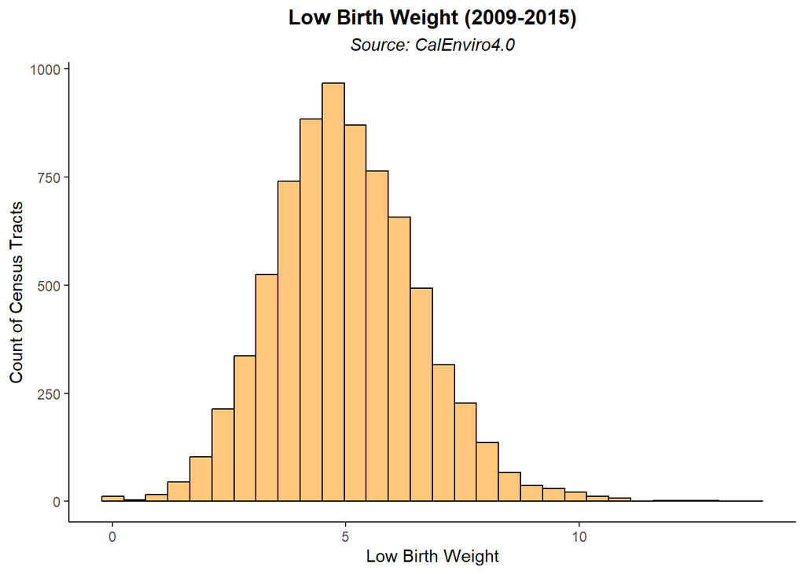

```r
ggplot(aes(x = low_birth_weight), data = ca_tracts) +
  geom_histogram(color = "black", fill = "#FFC77B") +
  labs(
    title = "Low Birth Weight (2009-2015)",
    subtitle = "Source: CalEnviro4.0",
    x = "Low Birth Weight",
    y = "Count of Census Tracts")
```

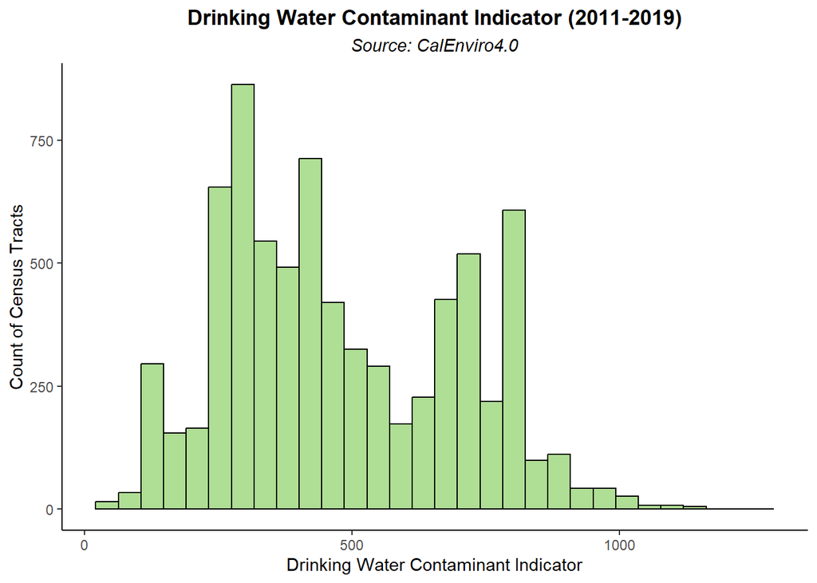

```r
ggsave("figures/lbw_hist.png", plot = last_plot(), height = 4, width = 6)

ggplot(aes(x = drinking_water), data = ca_tracts) +
  geom_histogram(color = "black", fill = "#AFDE95") +
  labs(
    title = "Drinking Water Contaminant Indicator (2011-2019)",
    subtitle = "Source: CalEnviro4.0",
    x = "Drinking Water Contaminant Indicator",
    y = "Count of Census Tracts")
```

```r
ggsave("figures/dwc_hist.png", plot = last_plot(), height = 4, width = 6)
```

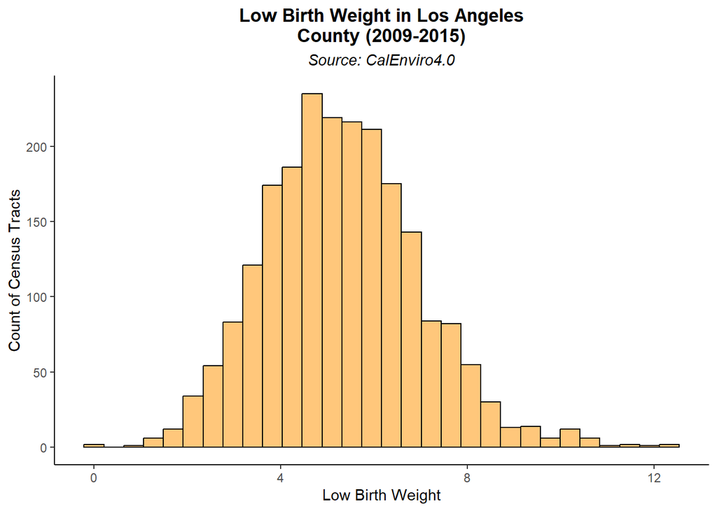

```r
ggplot(aes(x = low_birth_weight), data = la_tracts) +
  geom_histogram(color = "black", fill = "#FFC77B") +
  labs(
    title = "Low Birth Weight in Los Angeles\nCounty (2009-2015)",
    subtitle = "Source: CalEnviro4.0",
    x = "Low Birth Weight",
    y = "Count of Census Tracts")
```

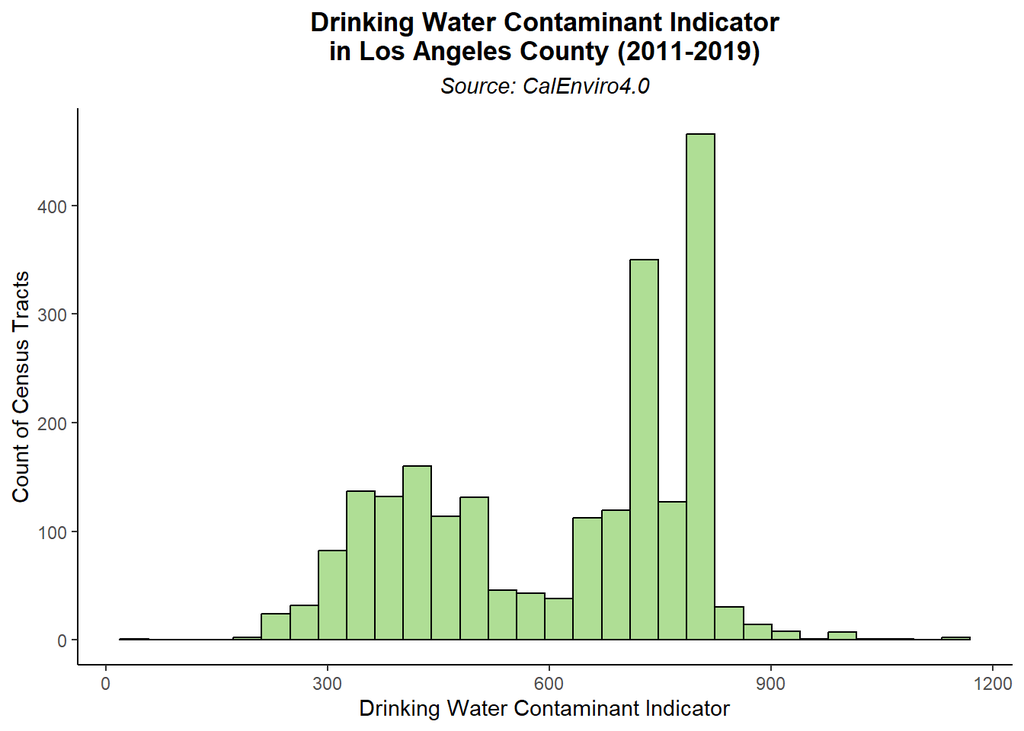

```r
ggplot(aes(x = drinking_water), data = la_tracts) +
  geom_histogram(color = "black", fill = "#AFDE95") +
  labs(
    title = "Drinking Water Contaminant Indicator\nin Los Angeles County (2011-2019)",
    subtitle = "Source: CalEnviro4.0",
    x = "Drinking Water Contaminant Indicator",
    y = "Count of Census Tracts")
```

## **Visualizations: Choropleths (California)**

California

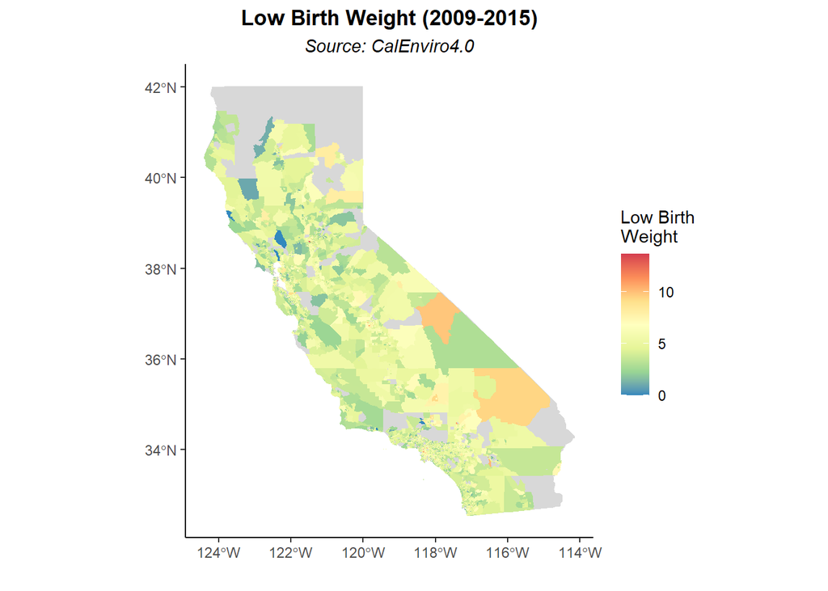

```r
# Outcome: LBW
ggplot() +
  geom_polygon(data = ca.map, aes(x = long, y = lat, group = group),
               fill = "grey", color = NA, alpha = 0.6) +
  geom_sf(color = NA, aes(fill = low_birth_weight), data = drop_na(ca_tracts)) +
  scale_fill_distiller(palette = "Spectral") +
  labs(
    title = "Low Birth Weight (2009-2015)",
    subtitle = "Source: CalEnviro4.0",
    fill = "Low Birth\nWeight",
    x = "", y = "")
```

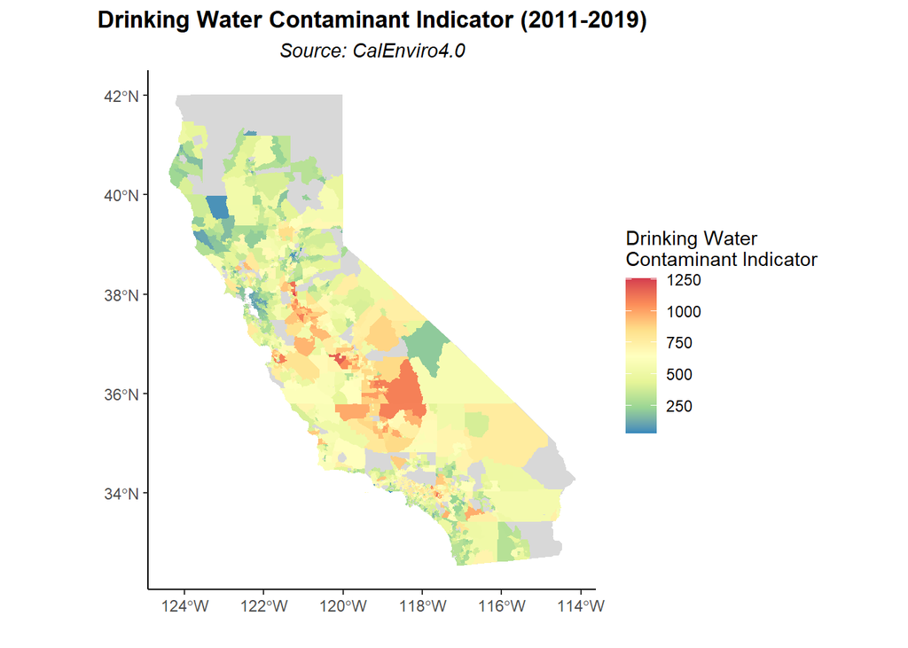

```r
# Predictor: DWC
ggplot() +
  geom_polygon(data = ca.map, aes(x = long, y = lat, group = group),
               fill = "grey", color = NA, alpha = 0.6) +
  geom_sf(color = NA, aes(fill = drinking_water), data = drop_na(ca_tracts)) +
  scale_fill_distiller(palette = "Spectral") +
  labs(
    title = "Drinking Water Contaminant Indicator (2011-2019)",
    subtitle = "Source: CalEnviro4.0",
    fill = "Drinking Water\nContaminant Indicator",
    x = "", y = "")
```

Outcome: LBW

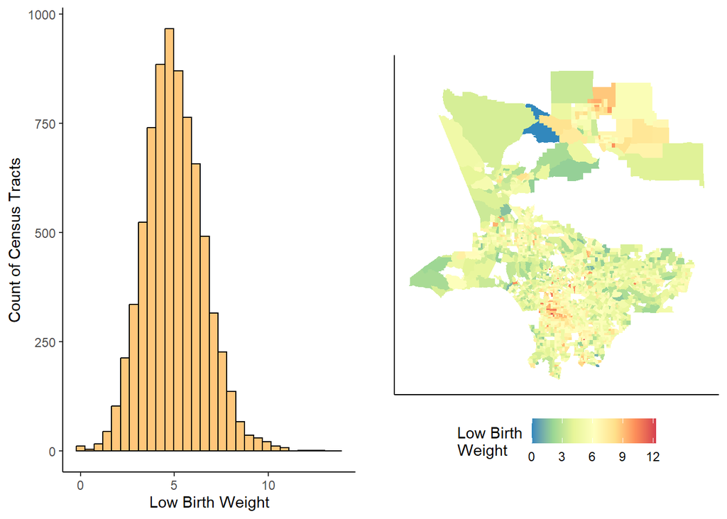

```r
hist.lbw = ggplot(aes(x = low_birth_weight), data = ca_tracts) +
  geom_histogram(color = "black", fill = "#FFC77B") +
  labs(
    # title = "Low Birth Weight (2009-2015)",
    # subtitle = "Source: CalEnviro4.0",
    x = "Low Birth Weight",
    y = "Count of Census Tracts")

chor.lbw = ggplot() +
  geom_sf(color = NA, aes(fill = low_birth_weight), data = la_tracts) +
  scale_fill_distiller(palette = "Spectral") +
  labs(
    # title = "Low Birth Weight (2009-2015)",
    # subtitle = "Source: CalEnviro4.0",
    fill = "Low Birth\nWeight",
    x = "", y = "") +
    theme(legend.position = "bottom",
          legend.box.spacing = unit(0, "cm"),
          legend.margin = margin(0, 0, 0, 0),
          axis.text = element_blank(),
          axis.ticks = element_blank())

# Generate combined plot
combined.plots.lbw = ggpubr::ggarrange(hist.lbw, chor.lbw) |>
  suppressMessages()
combined.plots.lbw
```

```r
# # Add title and subtitle
# ggpubr::annotate_figure(
#   combined.plots.lbw,
#   top = ggpubr::text_grob("Low Birth Weight (2009-2015)",
#                   color = "black", face = "bold", size = 16),
#   bottom = ggpubr::text_grob("Data Source: CalEnviroScreen4.0",
#                      size = 10, face = "italic")
# )

ggsave("figures/lbw_combined.png", plot = last_plot(), width = 11.5, height = 6.5, units = "in")
```

Predictor: DWC

```r
ca_tracts$drinking_water |> fivenum()
```

```
## [1]   32.56892  306.85440  433.34057  681.44790 1257.75423
```

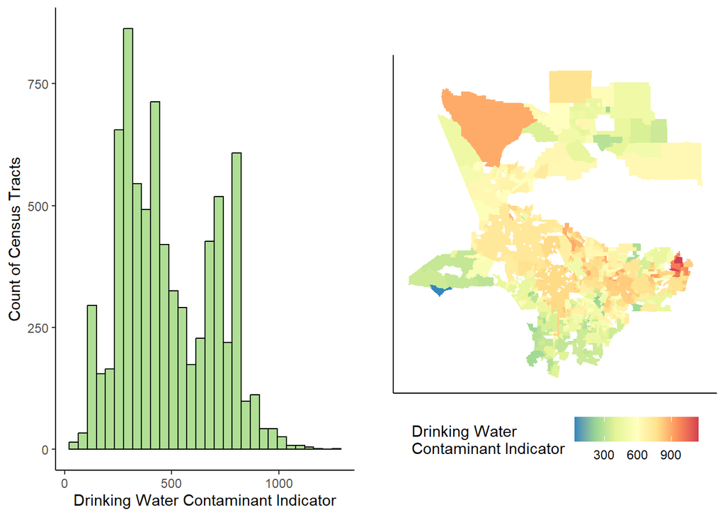

```r
hist.dwc = ggplot(aes(x = drinking_water), data = ca_tracts) +
  geom_histogram(color = "black", fill = "#AFDE95") +
  labs(
    # title = "Drinking Water Contaminant Indicator (2011-2019)",
    # subtitle = "Source: CalEnviro4.0",
    x = "Drinking Water Contaminant Indicator",
    y = "Count of Census Tracts")

chor.dwc = ggplot() +
  geom_sf(color = NA, aes(fill = drinking_water), data = la_tracts) +
  scale_fill_distiller(palette = "Spectral") +
  labs(
    # title = "Drinking Water Contaminant\nIndicator (2011-2019)",
    # subtitle = "Source: CalEnviro4.0",
    fill = "Drinking Water\nContaminant Indicator",
    x = "", y = "") +
    theme(legend.position = "bottom",
          legend.box.spacing = unit(0, "cm"),
          legend.margin = margin(0, 0, 0, 0),
          axis.text = element_blank(),
          axis.ticks = element_blank())

# Generate combined plot
combined.plots.dwc = ggpubr::ggarrange(hist.dwc, chor.dwc) |>
  suppressMessages()
combined.plots.dwc
```

```r
# # Add title and subtitle
# ggpubr::annotate_figure(
#   combined.plots.dwc,
#   top = ggpubr::text_grob("Drinking Water Contaminant\nIndicator (2011-2019)",
#                   color = "black", face = "bold", size = 16),
#   bottom = ggpubr::text_grob("Data Source: CalEnviroScreen4.0",
#                      size = 10, face = "italic")
# )

ggsave("figures/dwc_combined.png", plot = last_plot(), width = 11.5, height = 6.5, units = "in")
```

## **Visualizations: Covariate Plots**

Covariate Plots

```r
covar.list = c("total_birth_pop", "total_birth_count", "birthing_rate", "avg_birthing_age", "female_employment_rate", "unemployment_rate", "health_insurance_coverage", "poverty_rate_families", "poverty_rate_all", "residence_over_1y", "edu_less_than_hs", "edu_some_hs", "edu_hs", "edu_some_college", "edu_associate", "edu_bachelors", "edu_grad_prof", "fms_never_married", "foreign_born", "limited_english")

covar.meaning.list = c("Birthing Population", "Birth Count", "Birthing Rate", "Average Birthing Age", "Female Employment Rate", "Unemployment Rate", "Health Insurance Coverage (%)", "Poverty Rate (Families)", "Poverty Rate (All)", "Residential Stability (%)", "Less than HS (%)", "Some HS (%)", "HS Diploma (%)", "Some College (%)", "Associates Degree (%)", "Bachelors Degree (%)", "Graduate/Professional Degree (%)", "Unmarried Females (% Females)", "Foreign Born (%)", "Limited English (%)")

# cov.inv.list = c("avg_birthing_age", "female_employment_rate", "health_insurance_coverage", "residence_over_1y", "edu_hs", "edu_some_college", "edu_associate", "edu_bachelors", "edu_grad_prof")

for(i in 1:length(covar.list)){
  var = covar.list[i]
  title = covar.meaning.list[i]

  col_direction = ifelse(var %in% cov.inv.list, -1, 1)

  hist = ggplot(aes(x = !!sym(var)), data = la_tracts) +
    geom_histogram(color = "black", fill = "#8ED2BA") + #AFDE95
    labs(x = title) |>
    suppressMessages()

  chor = ggplot() +
    geom_sf(color = NA, aes(fill = !!sym(var)), data = la_tracts) +
    scale_fill_distiller(palette = "YlGnBu", direction = 1) + #Spectral
    labs(
      fill = title,
      x = "", y = "") +
    theme(legend.position = "bottom",
          legend.box.spacing = unit(0, "cm"),
          legend.margin = margin(0, 0, 0, 0),
          axis.text = element_blank(),
          axis.ticks = element_blank())

  ggpubr::ggarrange(hist, chor) |>
    suppressMessages()

  filename = paste0("figures/", var, ".png")
  ggsave(filename, plot = last_plot(), width = 11.5, height = 6.5, units = "in")
}
```

la_tracts |> colnames()

## **Spatial Dependence: Global Indicator (Moran’s I)**

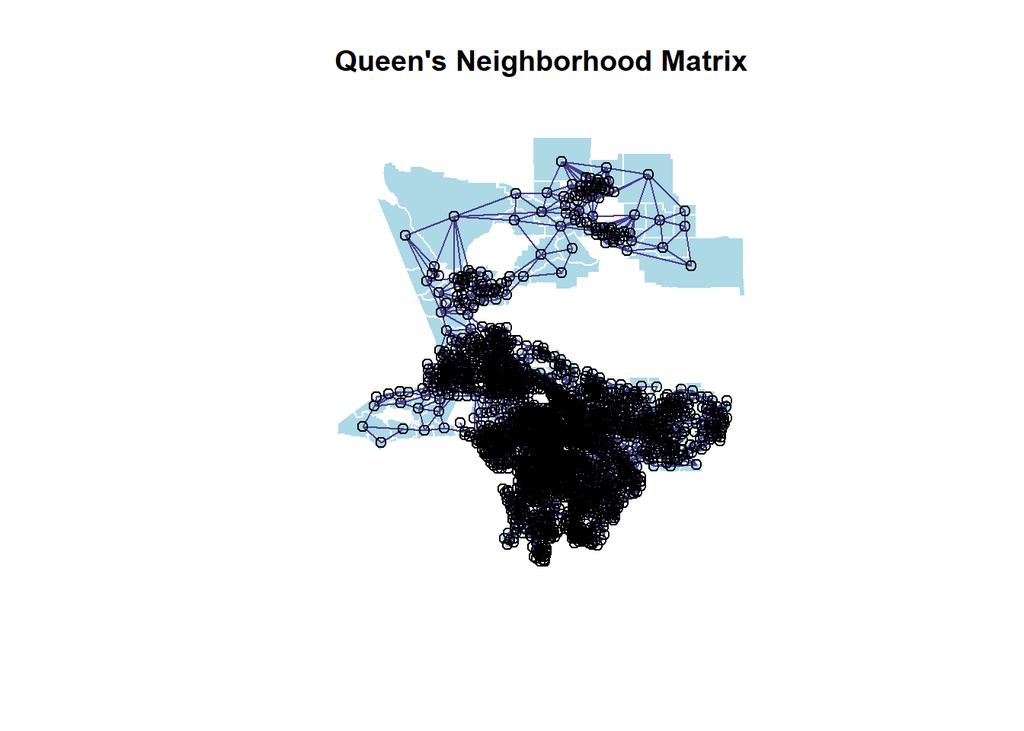

```r
# Create Queen's Neighborhood Matrix
nb = poly2nb(la_tracts)
weights = nb2listw(nb, zero.policy = TRUE)

# Troubleshooting Disconnected Sub-graphs
# la_tracts$subgraph_id = n.comp.nb(nb)$comp.id
# la_tracts$city[la_tracts$subgraph != 1] |> table()

plot(la_tracts$geometry, col = "lightblue", border = "white",
     main = "Queen's Neighborhood Matrix")
plot(nb, la_tracts$geometry, add = T, col = "darkslateblue")
```

```r
# Scale exposure and outcome data
la_tracts$lbw_scaled = scale(la_tracts$low_birth_weight)
la_tracts$dwc_scaled = scale(la_tracts$drinking_water)

# Create Lag
la_tracts$lbw_lag = lag.listw(weights, la_tracts$lbw_scaled)
la_tracts$dwc_lag = lag.listw(weights, la_tracts$dwc_scaled)

# Run Moran's I Test
moran.lbw = moran.test(la_tracts$lbw_scaled, listw = weights)
moran.dwc = moran.test(la_tracts$dwc_scaled, listw = weights)
```

Highly Significant Results

```r
# Print out Results
cat("Results:\n",
    "Morans I (LBW)\n",
    "\tStatistic: ", moran.lbw$estimate[1], "\n",
    "\tP-value: ", scales::scientific(moran.lbw$p.value), "\n",
    "Morans I (DWC)\n",
    "\tStatistic: ", moran.dwc$estimate[1], "\n",
    "\tP-value: ", scales::scientific(moran.dwc$p.value))
```

```
## Results:
##  Morans I (LBW)
##      Statistic:  0.3034244
##      P-value:  1.14e-127
##  Morans I (DWC)
##      Statistic:  0.8282718
##      P-value:  0e+00
```

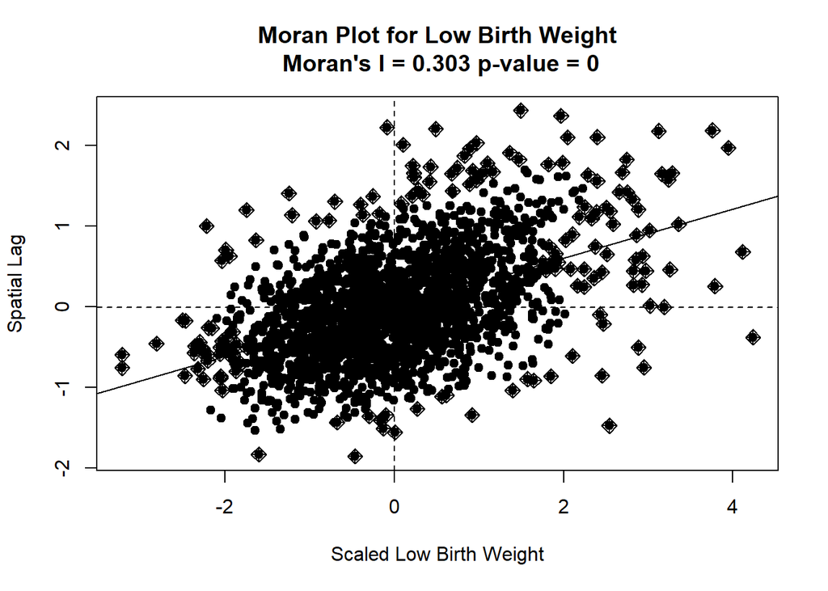

```r
moran.plot(as.vector(la_tracts$lbw_scaled), listw=weights,labels=F,
           #xlim=c(-10,10),ylim=c(-3,5),
           main=paste("Moran Plot for Low Birth Weight\n",
                      "Moran's I =", round(moran.lbw$estimate[1], 3),
                      "p-value =", round(moran.lbw$p.value, 3)),
           xlab="Scaled Low Birth Weight",ylab="Spatial Lag",pch=19)
```

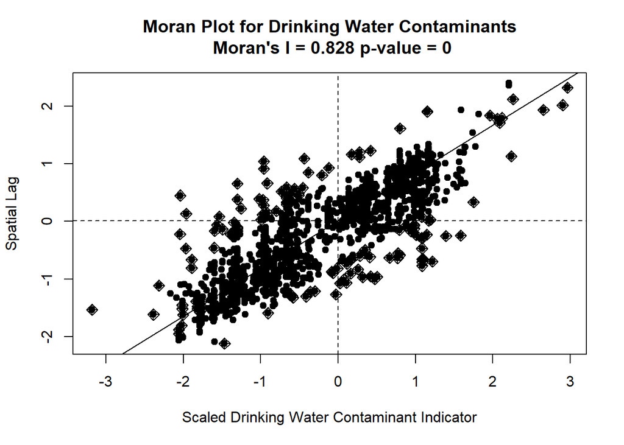

```r
moran.plot(as.vector(la_tracts$dwc_scaled), listw=weights,labels=F,
           #xlim=c(-10,10),ylim=c(-3,5),
           main=paste("Moran Plot for Drinking Water Contaminants\n",
                      "Moran's I =", round(moran.dwc$estimate[1], 3),
                      "p-value =", round(moran.dwc$p.value, 3)),
           xlab="Scaled Drinking Water Contaminant Indicator",ylab="Spatial Lag",pch=19)
```

## **Spatial Dependence: Local Indicator (LISA Clusters)**

Get Clusters

```r
# Get Lisa Clusters for LBW
lisa.lbw = localmoran(la_tracts$low_birth_weight, listw = weights)
la_tracts$lisa_p_lbw = lisa.lbw[, "Pr(z != E(Ii))"]
la_tracts$lisa_clusters_lbw = case_when(
  lisa.lbw[, "Ii"] > 0 & la_tracts$lbw_scaled > 0 & la_tracts$lisa_p_lbw <= 0.05 ~ "HH",
  lisa.lbw[, "Ii"] > 0 & la_tracts$lbw_scaled < 0 & la_tracts$lisa_p_lbw <= 0.05 ~ "LL",
  lisa.lbw[, "Ii"] < 0 & la_tracts$lbw_scaled > 0 & la_tracts$lisa_p_lbw <= 0.05 ~ "HL",
  lisa.lbw[, "Ii"] < 0 & la_tracts$lbw_scaled < 0 & la_tracts$lisa_p_lbw <= 0.05 ~ "LH",
  TRUE ~ "Non-Significant")

# Get Lisa Clusters for DWC
lisa.dwc = localmoran(la_tracts$drinking_water, listw = weights)
la_tracts$lisa_p_dwc = lisa.dwc[, "Pr(z != E(Ii))"]
la_tracts$lisa_clusters_dwc = case_when(
  lisa.dwc[, "Ii"] > 0 & la_tracts$dwc_scaled > 0 & la_tracts$lisa_p_dwc <= 0.05 ~ "HH",
  lisa.dwc[, "Ii"] > 0 & la_tracts$dwc_scaled < 0 & la_tracts$lisa_p_dwc <= 0.05 ~ "LL",
  lisa.dwc[, "Ii"] < 0 & la_tracts$dwc_scaled > 0 & la_tracts$lisa_p_dwc <= 0.05 ~ "HL",
  lisa.dwc[, "Ii"] < 0 & la_tracts$dwc_scaled < 0 & la_tracts$lisa_p_dwc <= 0.05 ~ "LH",
  TRUE ~ "Non-Significant")
```

Visualize

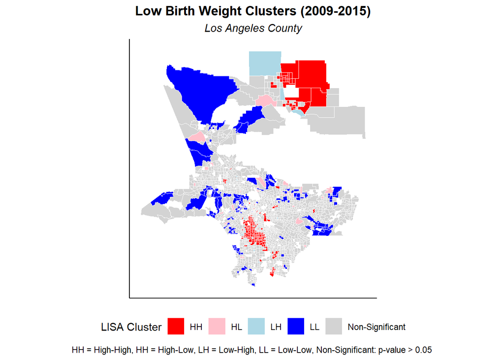

```r
lisa.lbw.plt = ggplot(data = la_tracts) +
  geom_sf(aes(fill = lisa_clusters_lbw), color = "white", linewidth = 0.1) +
  scale_fill_manual(values = c("HH" = "red", "LL" = "blue", "HL" = "pink", "LH" = "lightblue", "Non-Significant" = "lightgrey")) +
  labs(
    title = "Low Birth Weight Clusters (2009-2015)",
    subtitle = "Los Angeles County",
    fill = "LISA Cluster",
    caption = "HH = High-High, HH = High-Low, LH = Low-High, LL = Low-Low, Non-Significant: p-value > 0.05 ") +
  theme(axis.text = element_blank(), axis.ticks = element_blank(), legend.position = "bottom")
lisa.lbw.plt
```

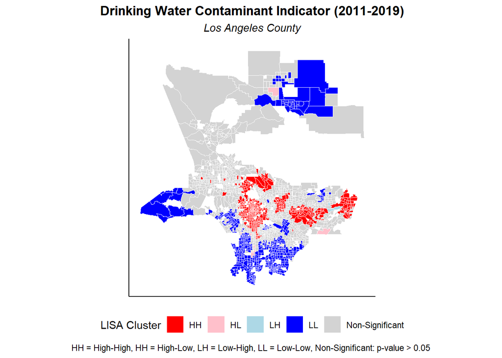

```r
ggsave("figures/lbw_lisa.png", plot = lisa.lbw.plt, width = 6, height = 6.5, units = "in")

lisa.dwc.plt = ggplot(data = la_tracts) +
  geom_sf(aes(fill = lisa_clusters_dwc), color = "white", linewidth = 0.1) +
  scale_fill_manual(values = c("HH" = "red", "LL" = "blue", "HL" = "pink", "LH" = "lightblue", "Non-Significant" = "lightgrey")) +
  labs(
    title = "Drinking Water Contaminant Indicator (2011-2019)",
    subtitle = "Los Angeles County",
    fill = "LISA Cluster",
    caption = "HH = High-High, HH = High-Low, LH = Low-High, LL = Low-Low, Non-Significant: p-value > 0.05 ") +
  theme(axis.text = element_blank(), axis.ticks = element_blank(), legend.position = "bottom")
lisa.dwc.plt
```

```r
ggsave("figures/dwc_lisa.png", plot = lisa.dwc.plt, width = 6, height = 6.5, units = "in")
```

Visualize

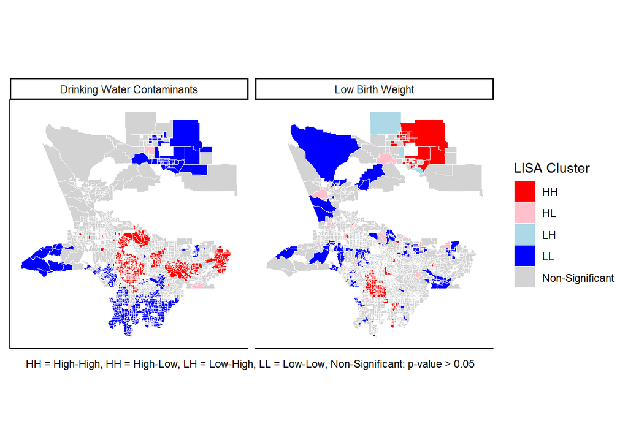

```r
# Temporary dataset
temp = la_tracts |>
  pivot_longer(
    cols = c(lisa_clusters_lbw, lisa_clusters_dwc),
    names_to = "val",
    values_to = "cluster"
  ) |>
  mutate(val = case_match(val,
                          "lisa_clusters_lbw" ~ "Low Birth Weight",
                          "lisa_clusters_dwc" ~ "Drinking Water Contaminants"))

ggplot(data = temp) +
  geom_sf(aes(fill = cluster), color = "white", linewidth = 0.1) +
  scale_fill_manual(values = c("HH" = "red", "LL" = "blue", "HL" = "pink", "LH" = "lightblue", "Non-Significant" = "lightgrey")) +
  facet_wrap(~ val) +
  labs(
    fill = "LISA Cluster",
    caption = "HH = High-High, HH = High-Low, LH = Low-High, LL = Low-Low, Non-Significant: p-value > 0.05 ") +
  theme(axis.text = element_blank(), axis.ticks = element_blank())
```

## **Spatial Regression: LA County**

Without Covariates

```r
reg.formula.nocovar = "low_birth_weight ~ drinking_water"
ols.fit1 = lm(reg.formula.nocovar, data = as.data.frame(la_tracts))
ols.fit1 |>
  broom::tidy() |>
  arrange(term != "(Intercept)", term != "drinking_water", p.value)
```

| term | estimate | std.error | statistic | p.value |
| --- | --- | --- | --- | --- |
| (Intercept) | 5.343792e+00 | 0.1244935941 | 42.924231 | 3.071268e-292 |
| drinking_water | -3.233399e-05 | 0.0001957986 | -0.165139 | 8.688499e-01 |

With Covariates

```r
covar.list = c("birthing_rate", "avg_birthing_age", "female_employment_rate", "unemployment_rate", "health_insurance_coverage", "poverty_rate_all", "residence_over_1y", "edu_hs", "fms_never_married", "foreign_born", "limited_english")

reg.formula = paste0("low_birth_weight ~ drinking_water + ", paste0(covar.list, collapse = " + ")) |> as.formula()

ols.fit = lm(reg.formula, data = as.data.frame(la_tracts))
ols.fit |>
  broom::tidy() |>
  arrange(term != "(Intercept)", term != "drinking_water", p.value)
```

| term | estimate | std.error | statistic | p.value |
| --- | --- | --- | --- | --- |
| (Intercept) | 4.3317465999 | 1.059152135 | 4.0898247 | 4.474698e-05 |
| drinking_water | -0.0003042319 | 0.000187702 | -1.6208242 | 1.052008e-01 |
| poverty_rate_all | 0.0304856015 | 0.005178723 | 5.8867030 | 4.554140e-09 |
| unemployment_rate | 0.0536094549 | 0.009175732 | 5.8425263 | 5.918593e-09 |
| edu_hs | 0.0252502925 | 0.005310618 | 4.7546802 | 2.118251e-06 |
| limited_english | -0.0255821110 | 0.007128065 | -3.5889278 | 3.394122e-04 |
| fms_never_married | 0.0150630947 | 0.004728339 | 3.1857050 | 1.464551e-03 |
| health_insurance_coverage | -0.0180533127 | 0.006849030 | -2.6358932 | 8.451474e-03 |
| birthing_rate | 0.0145773103 | 0.008059418 | 1.8087299 | 7.063153e-02 |
| female_employment_rate | -0.0081480259 | 0.004655120 | -1.7503362 | 8.020183e-02 |

[output cut: 3 more lines]

```r
reg.formula.dwc = paste0("drinking_water ~ ", paste0(covar.list, collapse = " + ")) |> as.formula()

ols.fit.dwc = lm(reg.formula, data = as.data.frame(la_tracts))
ols.fit.dwc |>
  broom::tidy() |>
  arrange(term != "(Intercept)", term != "drinking_water", p.value)
```

| term | estimate | std.error | statistic | p.value |
| --- | --- | --- | --- | --- |
| (Intercept) | 4.3317465999 | 1.059152135 | 4.0898247 | 4.474698e-05 |
| drinking_water | -0.0003042319 | 0.000187702 | -1.6208242 | 1.052008e-01 |
| poverty_rate_all | 0.0304856015 | 0.005178723 | 5.8867030 | 4.554140e-09 |
| unemployment_rate | 0.0536094549 | 0.009175732 | 5.8425263 | 5.918593e-09 |
| edu_hs | 0.0252502925 | 0.005310618 | 4.7546802 | 2.118251e-06 |
| limited_english | -0.0255821110 | 0.007128065 | -3.5889278 | 3.394122e-04 |
| fms_never_married | 0.0150630947 | 0.004728339 | 3.1857050 | 1.464551e-03 |
| health_insurance_coverage | -0.0180533127 | 0.006849030 | -2.6358932 | 8.451474e-03 |
| birthing_rate | 0.0145773103 | 0.008059418 | 1.8087299 | 7.063153e-02 |
| female_employment_rate | -0.0081480259 | 0.004655120 | -1.7503362 | 8.020183e-02 |

[output cut: 3 more lines]

```r
# Run Lagrange Multiplier tests to identify spatial regression model
lagrange = lm.RStests(ols.fit, weights, test = c("LMerr","RLMerr","LMlag","RLMlag","SARMA"))
print(lagrange)
```

```
##
##  Rao's score (a.k.a Lagrange multiplier) diagnostics for spatial
##  dependence
##
## data:
## model: lm(formula = reg.formula, data = as.data.frame(la_tracts))
## test weights: weights
##
## RSerr = 85.865, df = 1, p-value < 2.2e-16
##
##
##  Rao's score (a.k.a Lagrange multiplier) diagnostics for spatial
##  dependence
##
## data:
## model: lm(formula = reg.formula, data = as.data.frame(la_tracts))
## test weights: weights
##
## adjRSerr = 38.186, df = 1, p-value = 6.43e-10
##
##
##  Rao's score (a.k.a Lagrange multiplier) diagnostics for spatial
##  dependence
##
## data:
## model: lm(formula = reg.formula, data = as.data.frame(la_tracts))
## test weights: weights
##
## RSlag = 149.84, df = 1, p-value < 2.2e-16
##
##
##  Rao's score (a.k.a Lagrange multiplier) diagnostics for spatial
##  dependence
##
## data:
## model: lm(formula = reg.formula, data = as.data.frame(la_tracts))
## test weights: weights
##
## adjRSlag = 102.16, df = 1, p-value < 2.2e-16
##
##
##  Rao's score (a.k.a Lagrange multiplier) diagnostics for spatial
##  dependence
##
## data:
## model: lm(formula = reg.formula, data = as.data.frame(la_tracts))
## test weights: weights
##
## SARMA = 188.03, df = 2, p-value < 2.2e-16
```

Run Spatial Models and Compare

```r
lag.fit = spatialreg::lagsarlm(reg.formula, weights, data = la_tracts, tol.solve = 1.0e-15)
err.fit = spatialreg::errorsarlm(reg.formula, weights, data = la_tracts, tol.solve = 1.0e-15)
sar.fit = spatialreg::lagsarlm(reg.formula, weights, data = la_tracts, tol.solve = 1.0e-15, type = "mixed")
```

Summary Table

```r
# Print
cat(
  "Comparing Models:\n",
  "Basic Linear Model AIC: ", AIC(ols.fit), "\n",
  "Lag Spatial Model AIC: ", AIC(lag.fit), "\n",
  "Error Spatial Model AIC: ", AIC(err.fit), "\n",
  "Mixed Spatial Model AIC: ", AIC(sar.fit)
  )
```

```
## Comparing Models:
##  Basic Linear Model AIC:  7915.851
##  Lag Spatial Model AIC:  7793.242
##  Error Spatial Model AIC:  7836.993
##  Mixed Spatial Model AIC:  7766.016
```

```r
# GT Table
# Create a data frame with model names and AICs
aic_table = tibble::tibble(
  Model = c("Basic Linear Model", "Spatial Lag Model", "Spatial Error Model", "SARMA Model"),
  AIC = c(AIC(ols.fit), AIC(lag.fit), AIC(err.fit), AIC(sar.fit))
)

# Format the table
aic_gt = aic_table |>
  mutate(AIC = round(AIC, 2)) |>
  gt() |>
  tab_header(
    title = "Table 2. Model Comparison",
    subtitle = "Akaike Information Criterion (AIC) for Each Model"
  ) |>
  tab_style(
    style = cell_text(weight = "bold"),
    locations = list(
      cells_column_labels(everything())
    )
  ) |>
  cols_label(
    Model = "Model Type",
    AIC = "AIC Value"
  ) |>
  tab_options(
    table.font.size = "small",
    heading.align = "center"
  )
aic_gt
```

Table 2. Model Comparison

Akaike Information Criterion (AIC) for Each Model

| Model Type | AIC Value |
| --- | --- |
| Basic Linear Model | 7915.85 |
| Spatial Lag Model | 7793.24 |
| Spatial Error Model | 7836.99 |
| SARMA Model | 7766.02 |

```r
gtsave(aic_gt, "figures/aic_table.png")
```

```r
dwc.effect.summary =
  ols.fit |>
  broom::tidy() |>
  arrange(!term %in% c("rho", "(Intercept)", "drinking_water"), p.value) |>
  select(term, estimate, p.value) |>
  mutate(model = "Basic Linear Model") |>
  filter(term == "drinking_water") |>
  rbind(
    lag.fit |>
      broom::tidy() |>
      arrange(!term %in% c("rho", "(Intercept)", "drinking_water"), p.value) |>
      select(term, estimate, p.value) |>
      mutate(model = "Spatial Lag Model") |>
      filter(term == "drinking_water")
  ) |>
  rbind(
    err.fit |>
      broom::tidy() |>
      arrange(!term %in% c("rho", "(Intercept)", "drinking_water"), p.value) |>
      select(term, estimate, p.value) |>
      mutate(model = "Spatial Error Model") |>
      filter(term == "drinking_water")
  ) |>
  rbind(
    sar.fit |>
      broom::tidy() |>
      arrange(!term %in% c("rho", "(Intercept)", "drinking_water"), p.value) |>
      select(term, estimate, p.value) |>
      mutate(model = "SARMA Model") |>
      filter(term == "drinking_water")
  ) |>
  mutate(
    sig = case_when(
      p.value < 0.01 ~ "Highly significant (P-value < 0.01)",
      p.value < 0.05 ~ "Significant (P-value < 0.05)",
      p.value < 0.1 ~ "Moderate significance (P-value < 0.10)",
      p.value < 0.15 ~ "Low significance (P-value < 0.15)",
      TRUE ~ "Not significant")
  ) |>
  select(model, estimate, p.value, sig)
dwc.effect.summary
```

| model | estimate | p.value | sig |
| --- | --- | --- | --- |
| Basic Linear Model | -3.042319e-04 | 0.1052008 | Low significance (P-value < 0.15) |
| Spatial Lag Model | -2.506045e-04 | 0.1642073 | Not significant |
| Spatial Error Model | -2.811335e-04 | 0.2326124 | Not significant |
| SARMA Model | -2.945234e-05 | 0.9431873 | Not significant |

```r
dwc_summary_gt = dwc.effect.summary |>
  mutate(p.value = round(p.value, 5),
         estimate = round(estimate, 5)) |>
  gt() |>
  # Bold column headers and variable names
  tab_style(
    style = cell_text(weight = "bold"),
    locations = list(
      cells_column_labels(everything()))) |>
  # Format and relabel columns
  cols_label(
    model = "Model",
    estimate = "Effect Estimate",
    p.value = "P-value",
    sig = "Significance"
  ) |>
  tab_header(
    title = "Table 3. Effect of Drinking Water Contaminant Indicator on Low Birth Weight",
    subtitle = "Coefficient estimates and significance from four regression models") |>
  tab_options(
    table.font.size = "small",
    heading.align = "center")

dwc_summary_gt
```

Table 3. Effect of Drinking Water Contaminant Indicator on Low Birth Weight

Coefficient estimates and significance from four regression models

| Model | Effect Estimate | P-value | Significance |
| --- | --- | --- | --- |
| Basic Linear Model | -0.00030 | 0.10520 | Low significance (P-value < 0.15) |
| Spatial Lag Model | -0.00025 | 0.16421 | Not significant |
| Spatial Error Model | -0.00028 | 0.23261 | Not significant |
| SARMA Model | -0.00003 | 0.94319 | Not significant |

```r
gtsave(dwc_summary_gt, "figures/dwc_summary_table.png")
```

Generate Model Summary Table

```r
sar_summary = sar.fit |>
  broom::tidy() |>
  arrange(!term %in% c("rho", "(Intercept)", "drinking_water"), p.value) |>
  mutate(ci = paste0("(", round(estimate-1.96*std.error, 4),
                     ", ", round(estimate+1.96*std.error, 4), ")")) |>
  select(term, estimate, p.value, ci) |>
  mutate(
    sig = case_when(
      p.value < 0.01 ~ "Highly significant (P-value < 0.01)",
      p.value < 0.05 ~ "Significant (P-value < 0.05)",
      p.value < 0.1 ~ "Moderate significance (P-value < 0.10)",
      p.value < 0.15 ~ "Low significance (P-value < 0.15)",
      TRUE ~ "Not significant"),
    var_desc = case_when(
      term == "rho" ~ "Spatial Autoregressive Coefficient (ρ)",
      str_detect(term, "low_birth_weight") ~ "Low Birth Weight (%)",
      str_detect(term, "drinking_water") ~ "Drinking Water Contaminant Indicator",
      str_detect(term, "total_birth_pop") ~ "Birthing Population",
      str_detect(term, "total_birth_count") ~ "Birth Count",
      str_detect(term, "birthing_rate") ~ "Birthing Rate (%)",
      str_detect(term, "avg_birthing_age") ~ "Average Birthing Age",
      str_detect(term, "female_employment_rate") ~ "Female Employment Rate (%)",
      str_detect(term, "unemployment_rate") ~ "Unemployment Rate (%)",
      str_detect(term, "health_insurance_coverage") ~ "Health Insurance Coverage (%)",
      str_detect(term, "poverty_rate_families") ~ "Poverty Rate (Families)",
      str_detect(term, "poverty_rate_all") ~ "Poverty Rate (%)",
      str_detect(term, "residence_over_1y") ~ "Residential Stability (%)",
      str_detect(term, "edu_less_than_hs") ~ "Less than HS (%)",
      str_detect(term, "edu_some_hs") ~ "Some HS (%)",
      str_detect(term, "edu_hs") ~ "HS Diploma (%)",
      str_detect(term, "edu_some_college") ~ "Some College (%)",
      str_detect(term, "edu_associate") ~ "Associates Degree (%)",
      str_detect(term, "edu_bachelors") ~ "Bachelors Degree (%)",
      str_detect(term, "edu_grad_prof") ~ "Graduate/Professional Degree (%)",
      str_detect(term, "fms_never_married") ~ "Unmarried Females (% Females)",
      str_detect(term, "foreign_born") ~ "Foreign Born (%)",
      str_detect(term, "limited_english") ~ "Limited English (%)"),
    is_lag = ifelse(str_detect(term, "lag"), "Lagged", ""),
    var_title = paste(is_lag, var_desc)) |>
  drop_na() |>
  select(var_title, estimate, ci, p.value, sig)

sar_summary_gt = sar_summary |>
  mutate(p.value = round(p.value, 3),
         estimate = round(estimate, 3)) |>
  gt() |>
  # Bold column headers and variable names
  tab_style(
    style = cell_text(weight = "bold"),
    locations = list(
      cells_column_labels(everything()))) |>
  # Format and relabel columns
  cols_label(
    var_title = "Variable",
    estimate = "Effect Estimate",
    ci = "95% CI",
    p.value = "P-value",
    sig = "Significance"
  ) |>
  tab_header(
    title = "Table A.1. SARMA Model Results",
    subtitle = "Coefficients, Confidence Intervals (CI), and P-values") |>
  tab_options(
    table.font.size = "small",
    heading.align = "center")
sar_summary_gt
```

Table A.1. SARMA Model Results

Coefficients, Confidence Intervals (CI), and P-values

| Variable | Effect Estimate | 95% CI | P-value | Significance |
| --- | --- | --- | --- | --- |
| Spatial Autoregressive Coefficient (ρ) | 0.248 | (0.1852, 0.3107) | 0.000 | Highly significant (P-value < 0.01) |
| Drinking Water Contaminant Indicator | 0.000 | (-8e-04, 8e-04) | 0.943 | Not significant |
| Unemployment Rate (%) | 0.033 | (0.0146, 0.0512) | 0.000 | Highly significant (P-value < 0.01) |
| Poverty Rate (%) | 0.018 | (0.0076, 0.029) | 0.001 | Highly significant (P-value < 0.01) |
| Limited English (%) | -0.026 | (-0.042, -0.0096) | 0.002 | Highly significant (P-value < 0.01) |
| Lagged Average Birthing Age | 0.046 | (0.011, 0.0804) | 0.010 | Highly significant (P-value < 0.01) |
| Lagged Unemployment Rate (%) | 0.040 | (0.0053, 0.0745) | 0.024 | Significant (P-value < 0.05) |
| Foreign Born (%) | 0.016 | (0.001, 0.0313) | 0.037 | Significant (P-value < 0.05) |
| Lagged Residential Stability (%) | 0.022 | (2e-04, 0.0431) | 0.048 | Significant (P-value < 0.05) |
| Lagged Limited English (%) | -0.026 | (-0.052, -1e-04) | 0.049 | Significant (P-value < 0.05) |
| Lagged HS Diploma (%) | 0.019 | (-4e-04, 0.038) | 0.055 | Moderate significance (P-value < 0.10) |
| Lagged Poverty Rate (%) | 0.017 | (-0.0031, 0.0363) | 0.099 | Moderate significance (P-value < 0.10) |
| Birthing Rate (%) | 0.009 | (-0.0061, 0.0243) | 0.241 | Not significant |
| Lagged Foreign Born (%) | 0.011 | (-0.011, 0.0334) | 0.322 | Not significant |
| Lagged Unmarried Females (% Females) | 0.008 | (-0.0086, 0.0256) | 0.331 | Not significant |
| Health Insurance Coverage (%) | -0.007 | (-0.0211, 0.0072) | 0.338 | Not significant |
| Unmarried Females (% Females) | 0.005 | (-0.0052, 0.0143) | 0.362 | Not significant |
| Female Employment Rate (%) | -0.005 | (-0.0143, 0.0052) | 0.364 | Not significant |
| HS Diploma (%) | 0.006 | (-0.0081, 0.0191) | 0.425 | Not significant |
| Lagged Drinking Water Contaminant Indicator | 0.000 | (-0.0013, 6e-04) | 0.438 | Not significant |
| Lagged Health Insurance Coverage (%) | -0.006 | (-0.0313, 0.0184) | 0.611 | Not significant |
| Average Birthing Age | 0.002 | (-0.0133, 0.0172) | 0.802 | Not significant |
| Lagged Birthing Rate (%) | 0.004 | (-0.0307, 0.0381) | 0.833 | Not significant |
| Residential Stability (%) | -0.001 | (-0.0133, 0.0108) | 0.834 | Not significant |
| Lagged Female Employment Rate (%) | 0.001 | (-0.0161, 0.0177) | 0.929 | Not significant |

```r
gtsave(sar_summary_gt, "figures/sar_summary_table.png")
```

## **Linear Regression: Statewide**

CA Tracts Without Covariates

```r
reg.formula.nocovar = "low_birth_weight ~ drinking_water"
ols.fit.ca.nocovar = lm(reg.formula.nocovar, data = as.data.frame(ca_tracts))
ols.fit.ca.nocovar |>
  broom::tidy() |>
  arrange(term != "(Intercept)", term != "drinking_water", p.value)
```

| term | estimate | std.error | statistic | p.value |
| --- | --- | --- | --- | --- |
| (Intercept) | 4.675373 | 4.373665e-02 | 106.898281 | 0.000000e+00 |
| drinking_water | 0.000699 | 8.301519e-05 | 8.420146 | 4.463735e-17 |

With Covariates

```r
reg.formula.ca = paste0("low_birth_weight ~ drinking_water + ", paste0(covar.list, collapse = " + ")) |> as.formula()

ols.fit.ca = lm(reg.formula, data = as.data.frame(ca_tracts))
ols.fit.ca |>
  broom::tidy() |>
  arrange(term != "(Intercept)", term != "drinking_water", p.value)
```

| term | estimate | std.error | statistic | p.value |
| --- | --- | --- | --- | --- |
| (Intercept) | 9.326609e-01 | 4.831748e-01 | 1.9302763 | 5.361041e-02 |
| drinking_water | -8.694893e-05 | 8.039464e-05 | -1.0815264 | 2.794979e-01 |
| foreign_born | 3.505041e-02 | 2.873763e-03 | 12.1966962 | 6.786807e-34 |
| edu_hs | 3.105718e-02 | 2.679568e-03 | 11.5903694 | 8.447800e-31 |
| fms_never_married | 2.181749e-02 | 2.267534e-03 | 9.6216786 | 8.659369e-22 |
| poverty_rate_all | 2.242767e-02 | 2.690331e-03 | 8.3363961 | 9.034224e-17 |
| unemployment_rate | 3.593994e-02 | 4.421909e-03 | 8.1276989 | 5.080589e-16 |
| limited_english | -2.585257e-02 | 3.649926e-03 | -7.0830406 | 1.538644e-12 |
| birthing_rate | 1.577798e-02 | 3.954073e-03 | 3.9903100 | 6.661753e-05 |
| residence_over_1y | 8.442036e-03 | 2.602581e-03 | 3.2437175 | 1.184991e-03 |

[output cut: 3 more lines]

```r
reg.formula.ca.dwc = paste0("drinking_water ~ ", paste0(covar.list, collapse = " + ")) |> as.formula()

ols.fit.ca.dwc = lm(reg.formula, data = as.data.frame(ca_tracts))
ols.fit.ca.dwc |>
  broom::tidy() |>
  arrange(term != "(Intercept)", term != "drinking_water", p.value)
```

| term | estimate | std.error | statistic | p.value |
| --- | --- | --- | --- | --- |
| (Intercept) | 9.326609e-01 | 4.831748e-01 | 1.9302763 | 5.361041e-02 |
| drinking_water | -8.694893e-05 | 8.039464e-05 | -1.0815264 | 2.794979e-01 |
| foreign_born | 3.505041e-02 | 2.873763e-03 | 12.1966962 | 6.786807e-34 |
| edu_hs | 3.105718e-02 | 2.679568e-03 | 11.5903694 | 8.447800e-31 |
| fms_never_married | 2.181749e-02 | 2.267534e-03 | 9.6216786 | 8.659369e-22 |
| poverty_rate_all | 2.242767e-02 | 2.690331e-03 | 8.3363961 | 9.034224e-17 |
| unemployment_rate | 3.593994e-02 | 4.421909e-03 | 8.1276989 | 5.080589e-16 |
| limited_english | -2.585257e-02 | 3.649926e-03 | -7.0830406 | 1.538644e-12 |
| birthing_rate | 1.577798e-02 | 3.954073e-03 | 3.9903100 | 6.661753e-05 |
| residence_over_1y | 8.442036e-03 | 2.602581e-03 | 3.2437175 | 1.184991e-03 |

[output cut: 3 more lines]

## **Other Code**

For GWR or Regression

```r
# Get coordinates
# tracts.spdf = as_tibble(tracts)
# coordinates(tracts.spdf) = ~longitude+latitude
# proj4string(tracts.spdf) = CRS(st_crs(tracts)$wkt)
```